# Week 13 Worksheet

**Instructions:** Choose one group member to complete this worksheet on behalf of your entire group discussion. Worksheet must be handed in to Prof Suzy at the end of class.

You are going to design a simulation study (similar to the one we did in class regarding the ANOVA model) to investigate what “random noise” can look like in the context of a chi-square test for homogeneity. Please answer the following questions to the best of your groups’ ability as they are meant to guide you through this exercise.

1. What is the true, data-generating model that you will use to generate many observed data from? Recall, this model should reflect a scenario in which we would fail to reject the null hypothesis that the probabilities of each outcome are the same.

You can use whatever multinomial distribution you want but the one restriction is that the $k>2$ different levels/outcomes for your categorical variable should all occur with equal probability. (This is the definition of a homogenous multinomial distribution.)

In this example, I’ll generate observed data from a homogenous multinomial distribution accross $k=5$ different levels. To make this exercise more interesting, I’m going to generate a data set of size $n=25$ so we’d expect each of the $5$ levels to have about a handful of the $n$ observations. For now, let just generate a single observed data set:

```r
library(tidyverse)
numb_levels = 5
p_0 = 1/numb_levels
obs_data = rmultinom(n=1, size=25, prob=rep(p_0, numb_levels))
obs_data
```

```
##      [,1]
## [1,]    8
## [2,]    3
## [3,]    5
## [4,]    4
## [5,]    5
```

2. How many times will you generate new data sets and how will you summarize these (categorical) data?

You opinion may differ but personally, I think I’d like to simulate at least $100$ data sets (each of size $n=25$) to help me see if there’s a pattern to the observed data.

```r
experiments = 100
```

3. Do you see (in any of your simulated data sets) patterns that look like they come from a non-homogeneous population model? How often does this occur in your simulations?

This is more challenging to code so let’s start with just our first simulated data set and visualize these categorical data. Note one of the trickiest parts of this is getting the data into a format that can be recognized by R’s plots.

```r
obs_data_formatted = NULL

  for(j in 1:numb_levels){
    print(j)
    obs_data_formatted = c(obs_data_formatted, rep(paste0("Level ", j), obs_data[j,1]))
  }
```

```
## [1] 1
## [1] 2
## [1] 3
## [1] 4
## [1] 5
```

```r
obs_data_formatted <- data.frame(group=obs_data_formatted)
obs_data_formatted
```

| group |
| --- |
| Level 1 |
| Level 1 |
| Level 1 |
| Level 1 |
| Level 1 |
| Level 1 |
| Level 1 |
| Level 1 |
| Level 2 |
| Level 2 |

[output cut: 15 more lines]

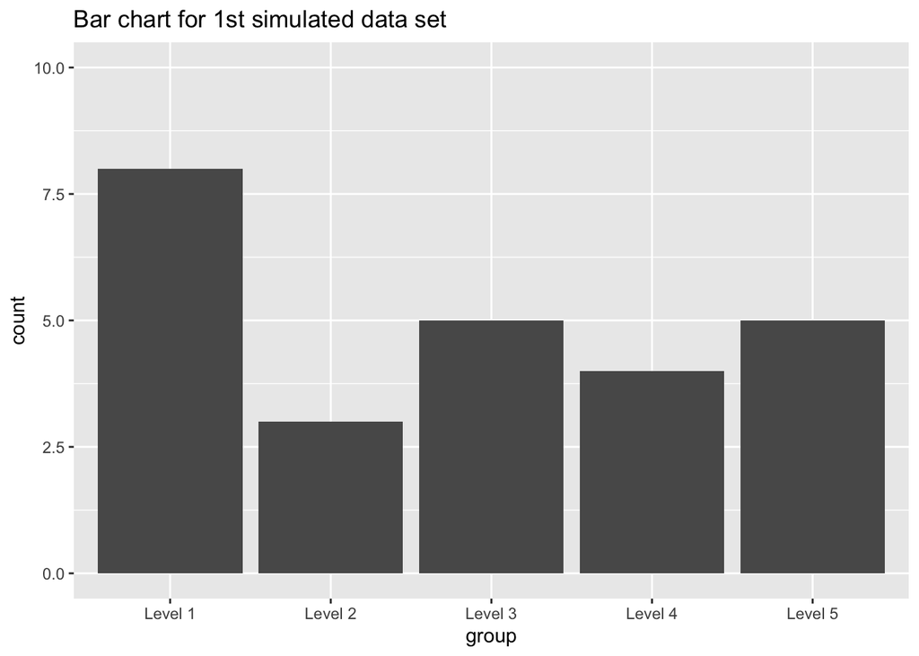

```r
ggplot(obs_data_formatted, aes(x=group)) +
  geom_bar() +
  labs(title= "Bar chart for 1st simulated data set") +
  ylim(0, 10)
```

Now to extend this to simulate and visualize $99$ other data sets, we need to follow the same idea but will need to produce $100$ total plots. There are many ways to do this code but here’s my solution (let me know if you think of something more effecient!):

```r
obs_data_full = matrix(rep(NA, experiments*numb_levels), nrow=experiments)
for(i in 1:experiments){
  obs_data_full[i,] = rmultinom(n=1, size=25, prob=rep(p_0, numb_levels))
}
obs_data_full
```

```
##        [,1] [,2] [,3] [,4] [,5]
##   [1,]    5    6    8    4    2
##   [2,]    4    5    2    6    8
##   [3,]    7    6    4    6    2
##   [4,]    6    2    6    2    9
##   [5,]    5    6    4    2    8
##   [6,]    6    5    4    5    5
##   [7,]    3    5    3    7    7
##   [8,]    5    6    5    3    6
##   [9,]    5    6    6    7    1
##  [10,]    3    5    9    1    7
##  [11,]    7    6    4    4    4
##  [12,]    5    4    8    3    5
##  [13,]    5    7    1    4    8
##  [14,]    6    6    2    7    4
```

[output cut: 86 more lines]

```r
colnames(obs_data_full) = c("Level 1", "Level 2", "Level 3", "Level 4", "Level 5")
obs_data_full
```

```
##        Level 1 Level 2 Level 3 Level 4 Level 5
##   [1,]       5       6       8       4       2
##   [2,]       4       5       2       6       8
##   [3,]       7       6       4       6       2
##   [4,]       6       2       6       2       9
##   [5,]       5       6       4       2       8
##   [6,]       6       5       4       5       5
##   [7,]       3       5       3       7       7
##   [8,]       5       6       5       3       6
##   [9,]       5       6       6       7       1
##  [10,]       3       5       9       1       7
##  [11,]       7       6       4       4       4
##  [12,]       5       4       8       3       5
##  [13,]       5       7       1       4       8
##  [14,]       6       6       2       7       4
```

[output cut: 86 more lines]

```r
t(obs_data_full)  ## this is the matrix transpose
```

```
##         [,1] [,2] [,3] [,4] [,5] [,6] [,7] [,8] [,9] [,10] [,11] [,12] [,13]
## Level 1    5    4    7    6    5    6    3    5    5     3     7     5     5
## Level 2    6    5    6    2    6    5    5    6    6     5     6     4     7
## Level 3    8    2    4    6    4    4    3    5    6     9     4     8     1
## Level 4    4    6    6    2    2    5    7    3    7     1     4     3     4
## Level 5    2    8    2    9    8    5    7    6    1     7     4     5     8
##         [,14] [,15] [,16] [,17] [,18] [,19] [,20] [,21] [,22] [,23] [,24] [,25]
## Level 1     6     5     3     5     8     5     7     6     5     4     2     5
## Level 2     6     5    11     7     2     3     6     3     4     2     4     4
## Level 3     2     3     7     6     6     4     4     2     6     4     6     8
## Level 4     7     8     3     4     4     9     5     5     5    11     8     3
## Level 5     4     4     1     3     5     4     3     9     5     4     5     5
##         [,26] [,27] [,28] [,29] [,30] [,31] [,32] [,33] [,34] [,35] [,36] [,37]
## Level 1     4     5     7     7     9     5     5     3     4     8     6     3
## Level 2     5     3     5     4     5     5     4     9     3     2     6     4
## Level 3     5     4     3     7     5     8     3     3     6     3     3     5
## Level 4     4     9     3     2     4     3     6     5     7     6     4     5
## Level 5     7     4     7     5     2     4     7     5     5     6     6     8
##         [,38] [,39] [,40] [,41] [,42] [,43] [,44] [,45] [,46] [,47] [,48] [,49]
## Level 1     7     3     5     8     7     6     7     6     7    11     3     6
## Level 2     6     2     4     3     3     5     8     5     7     5     5     6
## Level 3     4     8     7     8     7     4     3     3     4     1     5     2
## Level 4     6     6     5     2     3     4     4     4     5     3     6     6
## Level 5     2     6     4     4     5     6     3     7     2     5     6     5
##         [,50] [,51] [,52] [,53] [,54] [,55] [,56] [,57] [,58] [,59] [,60] [,61]
## Level 1     1     4     5     5     3     6     5     2     7     5     3     5
## Level 2     5     4     3     5     3     5     6    10     6     3     8     7
## Level 3     5     7     6     4     5     4     6     4     7     6     8     4
## Level 4    10     7     5     5     4     6     3     2     2     8     3     4
## Level 5     4     3     6     6    10     4     5     7     3     3     3     5
##         [,62] [,63] [,64] [,65] [,66] [,67] [,68] [,69] [,70] [,71] [,72] [,73]
## Level 1     7     3     5     5     4     6     7     3     5     2     3     4
## Level 2     6     6     3     4     2     8     3     6     3     5     6     6
## Level 3     3     6     3     5     4     4     2     5     8     5     9     4
## Level 4     6     5     3     5     5     5    10     5     3     6     4     3
## Level 5     3     5    11     6    10     2     3     6     6     7     3     8
##         [,74] [,75] [,76] [,77] [,78] [,79] [,80] [,81] [,82] [,83] [,84] [,85]
## Level 1     4     7     1     4     7     4     4     3     6     6     3     4
## Level 2     7     2     6     5     4     2    10     7     3     3     6     5
## Level 3     2     7     6     8     4     6     7     7     5     4     3     7
## Level 4     6     3     9     3     3     8     2     2     7     5     7     4
## Level 5     6     6     3     5     7     5     2     6     4     7     6     5
##         [,86] [,87] [,88] [,89] [,90] [,91] [,92] [,93] [,94] [,95] [,96] [,97]
## Level 1     6     2     8     4     2     6     6     5     1     4     6     4
## Level 2     3     2     4     6     2     3     5     4     5     3     3     4
## Level 3     5    10     4     2     9     8     4     4     8     3     6     3
## Level 4     6     6     3     5     7     3     2     6     4    12     4     7
## Level 5     5     5     6     8     5     5     8     6     7     3     6     7
##         [,98] [,99] [,100]
## Level 1     3     5      7
## Level 2     2     6      1
## Level 3     7     4      7
## Level 4     8     5      4
## Level 5     5     5      6
```

```r
plot_objects = list() ## lists are objects that are more general than data objects, we're going to create an empty list and store our 100 different plots in this list

for (i in 1:experiments){

  obs_data_formatted = NULL

  for(j in 1:numb_levels){
    obs_data_formatted = c(obs_data_formatted, rep(paste0("Level ", j), t(obs_data_full)[j,i]))
  }

  obs_data_formatted <- data.frame(group=obs_data_formatted)
  obs_data_formatted


plot_objects[[i]] <-  ggplot(obs_data_formatted, aes(x=group)) +
    geom_bar() +
    labs(title= paste0("Bar chart for simulated data set # ", i)) +
    ylim(0, 10)
}
```

Now you can visualize any of these $100$ experimental data sets by calling

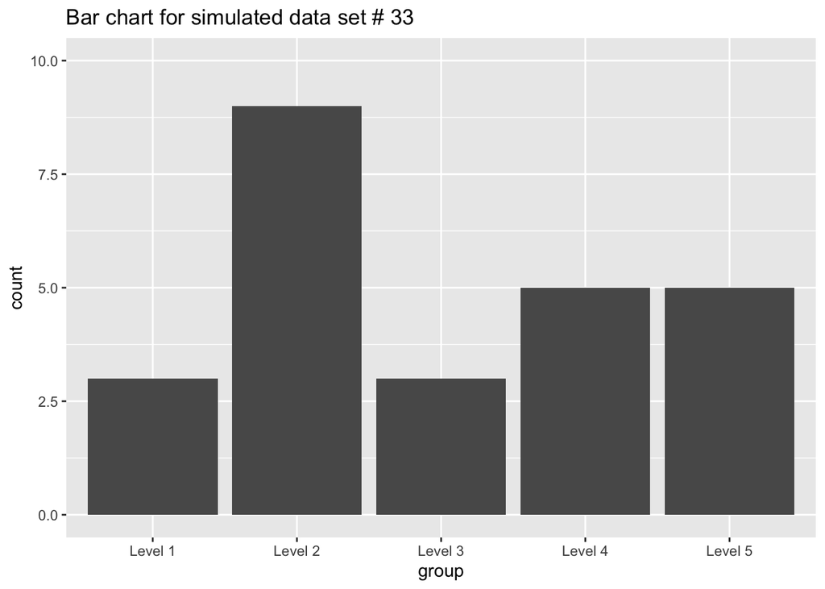

```r
k=33   ## sub any number from 1:100 here!
plot_objects[[k]]
```

Play around with this code and see if you can find an experiment where it visually looks like the data comes from a non-homogeneous distribution. This should be a rare occurance since we know that most of the time, the data will be evenly split among the levels. However, every once in a while, due to random chance (not due to an actual non-homogenous population), we see weird data that does not look balanced.